# Assignment 6

## Finalizing Features

### Load the Dataset and Initial Inspection

We begin by loading the healthcare dataset `inpatient_data.csv` and performing an initial inspection of the available features. This will help us understand the structure and ensure that no values are missing or corrupted.

The key features we'll focus on for anomaly detection include:

- **Payment_to_Charge_Ratio**: Reflects the proportion of Medicare payments to covered charges.
- **Discharges_per_Dollar**: Efficiency metric showing how many discharges are made per dollar spent.
- **charge_to_payment_ratio**: Captures discrepancies in how much is charged versus how much is paid.
- **discharge_efficiency**: Measures operational efficiency, useful for detecting outliers.
- **hospital_efficiency_score**: Combines operational and financial metrics to rate hospital efficiency.
- **Average Covered Charges**, **Average Total Payments**, and **Average Medicare Payments** are key financial metrics for anomaly detection.

We'll also identify and refine additional features to ensure we have a total of 12 for PCA and KNN analysis.

```python
# Importing necessary libraries
import pandas as pd
import numpy as np
import matplotlib.pyplot as plt
import seaborn as sns
```

```python
# Load the dataset
inpatient_data = pd.read_csv('/Users/dave.john.98/Desktop/APAN/Fall 24/Anomaly Detection/Week 7/inpatient_data.csv')

# Display dataset structure and inspect the first few rows
inpatient_data.info()
inpatient_data.head()

# Further inspection to ensure no missing values or anomalies
print("\nChecking for missing values:\n")
print(inpatient_data.isnull().sum())
```

```
<class 'pandas.core.frame.DataFrame'>
RangeIndex: 163065 entries, 0 to 163064
Data columns (total 30 columns):
 #   Column                                Non-Null Count   Dtype
---  ------                                --------------   -----
 0   DRG Definition                        163065 non-null  object
 1   Provider Id                           163065 non-null  int64
 2   Provider Name                         163065 non-null  object
 3   Provider Street Address               163065 non-null  object
 4   Provider City                         163065 non-null  object
 5   Provider State                        163065 non-null  object
 6   Provider Zip Code                     163065 non-null  int64
 7   Hospital Referral Region Description  163065 non-null  object
 8   Total Discharges                      163065 non-null  int64
 9   Average Covered Charges               163065 non-null  float64
 10  Average Total Payments                163065 non-null  float64
 11  Average Medicare Payments             163065 non-null  float64
 12  Provider Type                         163065 non-null  object
 13  Payment_to_Charge_Ratio               163065 non-null  float64
 14  Discharges_per_Dollar                 163065 non-null  float64
 15  Low_Discharges_per_Dollar_Flag        163065 non-null  int64
 16  Average_Payment_per_Discharge         163065 non-null  float64
 17  High_Payment_per_Discharge_Flag       163065 non-null  int64
 18  Coverage_Ratio                        163065 non-null  float64
 19  Low_Coverage_Ratio_Flag               163065 non-null  int64
 20  Discharges_per_Medicare_Payment       163065 non-null  float64
 21  Low_Discharges_per_Medicare_Flag      163065 non-null  int64
 22  DRG Category                          163065 non-null  object
 23  charge_to_payment_ratio               163065 non-null  float64
 24  discharge_efficiency                  163065 non-null  float64
 25  charge_to_payment_z                   163065 non-null  float64
 26  discharge_efficiency_z                163065 non-null  float64
 27  category_outlier_flag                 163065 non-null  bool
 28  hospital_efficiency_score             163065 non-null  float64
 29  log_hospital_efficiency_score         163065 non-null  float64
dtypes: bool(1), float64(14), int64(7), object(8)
memory usage: 36.2+ MB

Checking for missing values:

```

[output cut: 16 more lines]

```
Average_Payment_per_Discharge           0
High_Payment_per_Discharge_Flag         0
Coverage_Ratio                          0
Low_Coverage_Ratio_Flag                 0
Discharges_per_Medicare_Payment         0
Low_Discharges_per_Medicare_Flag        0
DRG Category                            0
charge_to_payment_ratio                 0
discharge_efficiency                    0
charge_to_payment_z                     0
discharge_efficiency_z                  0
category_outlier_flag                   0
hospital_efficiency_score               0
log_hospital_efficiency_score           0
dtype: int64
```

### Confirming Usable Features

After inspecting the dataset, we have confirmed **8 features** that are suitable for both PCA and KNN analysis. These features are free from missing values and relevant for anomaly detection:

1. **Payment_to_Charge_Ratio**: Reflects discrepancies in Medicare payments compared to charges.
2. **Discharges_per_Dollar**: Measures the number of discharges per dollar spent, indicating efficiency.
3. **Average_Payment_per_Discharge**: Shows how much is paid per discharge on average, useful for detecting overpayments.
4. **Coverage_Ratio**: Compares the amount covered to the total charges, highlighting financial inefficiencies.
5. **Discharges_per_Medicare_Payment**: Helps detect inefficiencies in how many discharges are made per Medicare dollar spent.
6. **hospital_efficiency_score**: Combines operational and financial metrics to assess overall hospital efficiency.
7. **charge_to_payment_ratio**: Captures the relationship between how much is charged and how much is paid, useful for billing discrepancies.
8. **discharge_efficiency**: Indicates how efficiently a hospital discharges patients, a key operational metric.

We will now move forward to refine or create additional features to reach a total of 12 usable features for our PCA and KNN analysis.

### Creating Feature 9 - Deviation of Average Covered Charges

To improve our anomaly detection, we introduce a new feature that calculates how far each provider’s **Average Covered Charges** deviate from the mean for their corresponding **DRG Definition**.

This feature is more informative for PCA and KNN since it introduces variability at the row level, as opposed to having repeated values within each DRG Definition. It will help detect providers with charges that significantly differ from others in the same category.

```python
# Create a new feature: deviation from the mean average covered charges for each DRG Definition
inpatient_data['Avg Covered Charge Deviation'] = (
    inpatient_data['Average Covered Charges'] - inpatient_data.groupby('DRG Definition')['Average Covered Charges'].transform('mean')
) / inpatient_data.groupby('DRG Definition')['Average Covered Charges'].transform('std')

# Display the first few rows to inspect the new feature
inpatient_data[['DRG Definition', 'Average Covered Charges', 'Avg Covered Charge Deviation']].head()
```

|  | DRG Definition | Average Covered Charges | Avg Covered Charge Deviation |
| --- | --- | --- | --- |
| 0 | 039 - EXTRACRANIAL PROCEDURES W/O CC/MCC | 32963.07 | 0.155639 |
| 1 | 039 - EXTRACRANIAL PROCEDURES W/O CC/MCC | 15131.85 | -0.962919 |
| 2 | 039 - EXTRACRANIAL PROCEDURES W/O CC/MCC | 37560.37 | 0.444029 |
| 3 | 039 - EXTRACRANIAL PROCEDURES W/O CC/MCC | 13998.28 | -1.034028 |
| 4 | 039 - EXTRACRANIAL PROCEDURES W/O CC/MCC | 31633.27 | 0.072220 |

### Creating Feature 10 - Provider Type Discharge Deviation

To enhance our anomaly detection, we introduce a new feature that calculates the deviation of each provider’s **Total Discharges** from the mean of their respective **Provider Type**.

This allows us to capture how a provider's discharge volume compares to the typical volume for their type. This method introduces variability at the provider level, making it more effective for PCA and KNN.

```python
# Calculate the deviation of total discharges from the mean by provider type
inpatient_data['Provider Type Discharge Deviation'] = (
    inpatient_data['Total Discharges'] - inpatient_data.groupby('Provider Type')['Total Discharges'].transform('mean')
) / inpatient_data.groupby('Provider Type')['Total Discharges'].transform('std')

# Display the first few rows to inspect the new feature
inpatient_data[['Provider Type', 'Total Discharges', 'Provider Type Discharge Deviation']].head()
```

|  | Provider Type | Total Discharges | Provider Type Discharge Deviation |
| --- | --- | --- | --- |
| 0 | Medical Center | 91 | 1.065344 |
| 1 | Medical Center | 14 | -0.599682 |
| 2 | Hospital | 24 | -0.360098 |
| 3 | Other | 25 | -0.288988 |
| 4 | Medical Center | 18 | -0.513187 |

### Creating Feature 11 - DRG Complexity Score

We refine the DRG Complexity Score to calculate a **weighted average complexity score** for each provider, based on the procedures they handle. The provider’s score is weighted by the number of cases of each DRG they handle.

```python
# Calculate the DRG complexity score based on Average Covered Charges for each DRG Definition
drg_complexity = inpatient_data.groupby('DRG Definition')['Average Covered Charges'].mean()

# Map the DRG complexity score to the dataset
inpatient_data['DRG Complexity Score'] = inpatient_data['DRG Definition'].map(drg_complexity)

# Calculate the weighted DRG complexity score for each provider
inpatient_data['Weighted DRG Complexity Score'] = (
    inpatient_data['DRG Complexity Score'] * inpatient_data['Total Discharges']
) / inpatient_data.groupby('Provider Id')['Total Discharges'].transform('sum')

# Display the first few rows to inspect the new feature
inpatient_data[['Provider Id', 'DRG Definition', 'Total Discharges', 'Weighted DRG Complexity Score']].head()
```

|  | Provider Id | DRG Definition | Total Discharges | Weighted DRG Complexity Score |
| --- | --- | --- | --- | --- |
| 0 | 10001 | 039 - EXTRACRANIAL PROCEDURES W/O CC/MCC | 91 | 513.202706 |
| 1 | 10005 | 039 - EXTRACRANIAL PROCEDURES W/O CC/MCC | 14 | 300.738400 |
| 2 | 10006 | 039 - EXTRACRANIAL PROCEDURES W/O CC/MCC | 24 | 187.533360 |
| 3 | 10011 | 039 - EXTRACRANIAL PROCEDURES W/O CC/MCC | 25 | 261.244300 |
| 4 | 10016 | 039 - EXTRACRANIAL PROCEDURES W/O CC/MCC | 18 | 217.814898 |

### Creating Feature 12 - Patient Complexity Ratio

We introduce the **Patient Complexity Ratio** to measure how specialized or generalized a provider is in terms of the number of discharges they handle relative to the variety of **DRG Definitions**. A higher ratio suggests the provider handles many discharges for a smaller set of procedures (specialized), while a lower ratio indicates a more generalized approach across many different DRGs.

This feature offers unique insights into provider specialization and patient throughput.

```python
# Calculate the number of unique DRG Definitions handled by each provider
unique_drgs_per_provider = inpatient_data.groupby('Provider Id')['DRG Definition'].nunique()

# Map the number of unique DRGs back to the dataset
inpatient_data['Unique DRG Count'] = inpatient_data['Provider Id'].map(unique_drgs_per_provider)

# Calculate the Patient Complexity Ratio
inpatient_data['Patient Complexity Ratio'] = inpatient_data['Total Discharges'] / inpatient_data['Unique DRG Count']

# Display the first few rows to inspect the new feature
inpatient_data[['Provider Id', 'Total Discharges', 'Unique DRG Count', 'Patient Complexity Ratio']].head()
```

|  | Provider Id | Total Discharges | Unique DRG Count | Patient Complexity Ratio |
| --- | --- | --- | --- | --- |
| 0 | 10001 | 91 | 92 | 0.989130 |
| 1 | 10005 | 14 | 49 | 0.285714 |
| 2 | 10006 | 24 | 86 | 0.279070 |
| 3 | 10011 | 25 | 87 | 0.287356 |
| 4 | 10016 | 18 | 80 | 0.225000 |

## Preparing Features for Analysis

Now that we have finalized our 12 features, we need to prepare the dataset for PCA and KNN analysis. This includes:

1. **Checking for null values**: Ensuring there are no missing values in our selected features.
2. **Verifying data types**: Making sure all features have appropriate data types (e.g., numeric for PCA and KNN).
3. **Checking for repeated values**: Ensuring that none of the features have too many repeated values, which could hinder the effectiveness of anomaly detection.

```python
# List of the 12 finalized features for analysis
final_features = [
    'Payment_to_Charge_Ratio',
    'Discharges_per_Dollar',
    'Average_Payment_per_Discharge',
    'Coverage_Ratio',
    'Discharges_per_Medicare_Payment',
    'hospital_efficiency_score',
    'charge_to_payment_ratio',
    'discharge_efficiency',
    'Avg Covered Charge Deviation',
    'Provider Type Discharge Deviation',
    'Weighted DRG Complexity Score',
    'Patient Complexity Ratio'
]

# Subset the dataset to include only the final features
subset_data = inpatient_data[final_features]

# Check for null values in the subset
null_values = subset_data.isnull().sum()

# Check data types of the selected features
data_types = subset_data.dtypes

# Inspect unique values in each feature to check for too many repeated values
repeated_value_check = subset_data.nunique()

# Display the results
print("Null Values in Each Feature:\n", null_values)
print("\nData Types of Each Feature:\n", data_types)
print("\nUnique Values in Each Feature:\n", repeated_value_check)
```

```
Null Values in Each Feature:
 Payment_to_Charge_Ratio              0
Discharges_per_Dollar                0
Average_Payment_per_Discharge        0
Coverage_Ratio                       0
Discharges_per_Medicare_Payment      0
hospital_efficiency_score            0
charge_to_payment_ratio              0
discharge_efficiency                 0
Avg Covered Charge Deviation         0
Provider Type Discharge Deviation    0
Weighted DRG Complexity Score        0
Patient Complexity Ratio             0
dtype: int64

Data Types of Each Feature:
 Payment_to_Charge_Ratio              float64
Discharges_per_Dollar                float64
Average_Payment_per_Discharge        float64
Coverage_Ratio                       float64
Discharges_per_Medicare_Payment      float64
hospital_efficiency_score            float64
charge_to_payment_ratio              float64
discharge_efficiency                 float64
Avg Covered Charge Deviation         float64
Provider Type Discharge Deviation    float64
Weighted DRG Complexity Score        float64
Patient Complexity Ratio             float64
dtype: object

Unique Values in Each Feature:
 Payment_to_Charge_Ratio              163064
Discharges_per_Dollar                160548
Average_Payment_per_Discharge        160891
Coverage_Ratio                       163044
Discharges_per_Medicare_Payment      160808
hospital_efficiency_score            162560
charge_to_payment_ratio              163062
discharge_efficiency                 162560
Avg Covered Charge Deviation         163014
Provider Type Discharge Deviation      1590
Weighted DRG Complexity Score        159686
Patient Complexity Ratio               8416
dtype: int64
```

### Takeaways

After inspecting the finalized 12 features, we can confirm that the dataset is ready for PCA and KNN analysis. Here’s a summary of the checks:

1. **Null Values**: None of the features contain any null values, ensuring that there are no missing data points that could disrupt the analysis.
2. **Data Types**: All features are of type **float64**, which is appropriate for both PCA and KNN since these methods require numeric input.
3. **Unique Values**: Most of the features have a large number of unique values, which will allow PCA and KNN to effectively capture variance and distance-based relationships.
   - **Provider Type Discharge Deviation** has fewer unique values, but this is expected since there are only a few provider types. The feature still adds value by capturing deviations within each provider type.

Overall, the features are in good condition and ready to be scaled before applying PCA and KNN for anomaly detection.

## K-Nearest Neighbors (KNN) for Anomaly Detection

We now apply **K-Nearest Neighbors (KNN)** from the **PyOD** library to detect anomalies in the dataset. KNN works by calculating the distance between points and identifying those that are farthest away from their neighbors, which could indicate potential anomalies.

#### Steps:

1. We will use the `KNN` implementation from **PyOD**.
2. The contamination rate is set to `0.05`, meaning we expect around 5% of the data to be anomalous.
3. We will fit the KNN model on our training data and use the model to predict anomalies in both the training and test datasets.

```python
# Import necessary modules
from pyod.models.knn import KNN
from sklearn.model_selection import train_test_split
from sklearn.preprocessing import StandardScaler

# Split the dataset into training and test sets (70/30 split)
X_train, X_test = train_test_split(subset_data, test_size=0.30, random_state=42)

# Scale the training and test sets
scaler = StandardScaler()
X_train_scaled = scaler.fit_transform(X_train)
X_test_scaled = scaler.transform(X_test)

# Train the KNN model
knn = KNN(contamination=0.05)  # Set contamination rate (expected outliers)
knn.fit(X_train_scaled)

# Get the KNN decision scores and predictions for the training data
y_train_scores = knn.decision_function(X_train_scaled)  # Decision scores for train set
y_train_pred = knn.predict(X_train_scaled)  # Predictions (0: normal, 1: anomaly)

# Get the KNN decision scores and predictions for the test data
y_test_scores = knn.decision_function(X_test_scaled)  # Decision scores for test set
y_test_pred = knn.predict(X_test_scaled)  # Predictions (0: normal, 1: anomaly)

# Define the utility function for counting anomaly stats
def count_stat(vector):
    # Because it is '0' and '1', we can run a count statistic.
    unique, counts = np.unique(vector, return_counts=True)
    return dict(zip(unique, counts))

# Display stats using count_stat for both training and test data
print(f"Anomalies (1) vs Normal (0) in Train Data: {count_stat(y_train_pred)}")
print(f"Anomalies (1) vs Normal (0) in Test Data: {count_stat(y_test_pred)}")

# Print the threshold used for defining anomalies (based on contamination rate)
print("The threshold for the defined contamination rate:", knn.threshold_)
```

```
Anomalies (1) vs Normal (0) in Train Data: {np.int64(0): np.int64(109084), np.int64(1): np.int64(5061)}
Anomalies (1) vs Normal (0) in Test Data: {np.int64(0): np.int64(46498), np.int64(1): np.int64(2422)}
The threshold for the defined contamination rate: 0.7458324855618828
```

### KNN Results and Takeaways

After applying the **K-Nearest Neighbors (KNN)** model, we observe the following results:

- In the **training data**, the model identified **5,061 anomalies** out of **114,145 records**. This suggests that approximately **4.43%** of the training data points were flagged as potential anomalies.
- In the **test data**, the model detected **2,422 anomalies** out of **48,920 records**, meaning about **4.95%** of the test data was classified as anomalous.

The **contamination threshold** used to define these anomalies was **0.7458**, meaning that data points with a decision score above this threshold were flagged as anomalies. The results align with our initial contamination rate assumption of 5%, indicating that the KNN model effectively captured potential outliers in both the training and test datasets.

### Visualizing KNN Decision Scores

In order to better understand how the KNN model has classified data points, we will visualize the decision scores. By plotting the scores in a histogram, we can see the distribution of the values and better understand how the model is identifying outliers. This helps in verifying the model's ability to detect anomalies.

We will plot the decision scores for both the **training set** and **test set**.

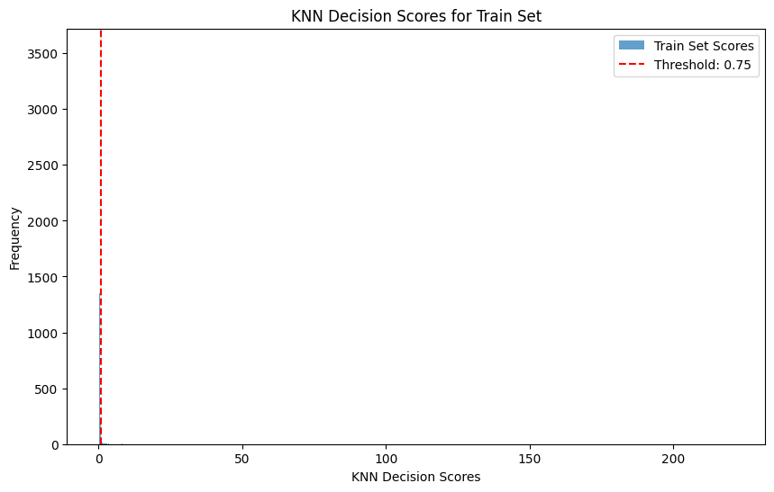

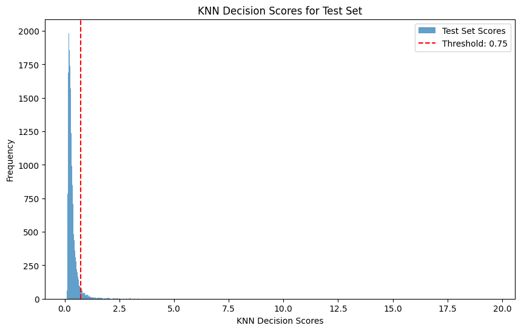

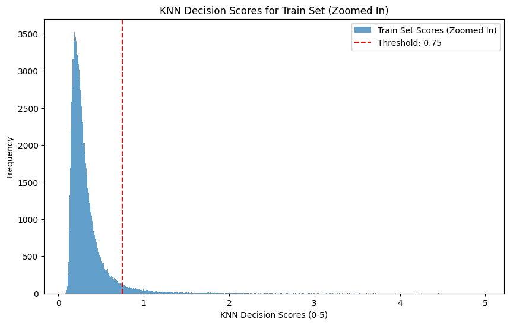

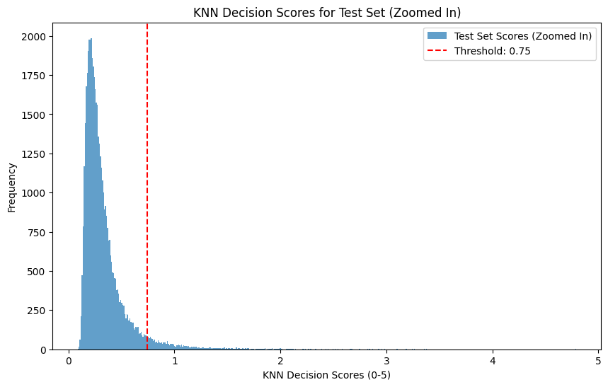

```python
# Plot the decision scores for the training set
plt.figure(figsize=(10, 6))
plt.hist(y_train_scores, bins='auto', alpha=0.7, label='Train Set Scores')
plt.axvline(knn.threshold_, color='r', linestyle='--', label=f'Threshold: {knn.threshold_:.2f}')
plt.title('KNN Decision Scores for Train Set')
plt.xlabel('KNN Decision Scores')
plt.ylabel('Frequency')
plt.legend()
plt.show()

# Plot the decision scores for the test set
plt.figure(figsize=(10, 6))
plt.hist(y_test_scores, bins='auto', alpha=0.7, label='Test Set Scores')
plt.axvline(knn.threshold_, color='r', linestyle='--', label=f'Threshold: {knn.threshold_:.2f}')
plt.title('KNN Decision Scores for Test Set')
plt.xlabel('KNN Decision Scores')
plt.ylabel('Frequency')
plt.legend()
plt.show()

# Zoom in on scores between 0 and 5 for a clearer look
plt.figure(figsize=(10, 6))
plt.hist([score for score in y_train_scores if score <= 5], bins='auto', alpha=0.7, label='Train Set Scores (Zoomed In)')
plt.axvline(knn.threshold_, color='r', linestyle='--', label=f'Threshold: {knn.threshold_:.2f}')
plt.title('KNN Decision Scores for Train Set (Zoomed In)')
plt.xlabel('KNN Decision Scores (0-5)')
plt.ylabel('Frequency')
plt.legend()
plt.show()

# Zoom in on scores between 0 and 5 for test set
plt.figure(figsize=(10, 6))
plt.hist([score for score in y_test_scores if score <= 5], bins='auto', alpha=0.7, label='Test Set Scores (Zoomed In)')
plt.axvline(knn.threshold_, color='r', linestyle='--', label=f'Threshold: {knn.threshold_:.2f}')
plt.title('KNN Decision Scores for Test Set (Zoomed In)')
plt.xlabel('KNN Decision Scores (0-5)')
plt.ylabel('Frequency')
plt.legend()
plt.show()
```

### Analyzing Descriptive Statistics for Anomalies and Normal Points

In this step, we will analyze and compare the **descriptive statistics** for anomalies and normal data points in the training set. By doing this, we can better understand the characteristics of the flagged anomalies and how they differ from the rest of the dataset.

We will separate the data points into **anomalies** (identified by KNN) and **normal** data points. For each group, we will calculate the summary statistics of the features.

```python
# Separate anomalies and normal data in the training set
anomalies_train = X_train_scaled[y_train_pred == 1]
normal_train = X_train_scaled[y_train_pred == 0]

# Convert to DataFrame for easier inspection
anomalies_train_df = pd.DataFrame(anomalies_train, columns=subset_data.columns)
normal_train_df = pd.DataFrame(normal_train, columns=subset_data.columns)

# Display descriptive statistics for anomalies and normal points
print("Descriptive statistics for anomalies in the training set:")
display(anomalies_train_df.describe())

print("Descriptive statistics for normal points in the training set:")
display(normal_train_df.describe())
```

```
Descriptive statistics for anomalies in the training set:
```

|  | Payment_to_Charge_Ratio | Discharges_per_Dollar | Average_Payment_per_Discharge | Coverage_Ratio | Discharges_per_Medicare_Payment | hospital_efficiency_score | charge_to_payment_ratio | discharge_efficiency | Avg Covered Charge Deviation | Provider Type Discharge Deviation | Weighted DRG Complexity Score | Patient Complexity Ratio |
| --- | --- | --- | --- | --- | --- | --- | --- | --- | --- | --- | --- | --- |
| count | 5061.000000 | 5061.000000 | 5061.000000 | 5061.000000 | 5061.000000 | 5061.000000 | 5061.000000 | 5061.000000 | 5061.000000 | 5061.000000 | 5061.000000 | 5061.000000 |
| mean | -0.106945 | 1.121472 | 0.706425 | -0.222281 | 1.113749 | 1.013984 | 0.617296 | 1.013984 | 0.980051 | 1.696148 | 1.719043 | 0.630781 |
| std | 1.486267 | 2.830816 | 2.480571 | 1.503701 | 2.809062 | 2.879504 | 1.714728 | 2.879504 | 1.914618 | 3.168837 | 4.158340 | 4.689922 |
| min | -1.566721 | -0.810246 | -0.801893 | -9.109219 | -0.785828 | -0.726134 | -1.904612 | -0.726134 | -1.941823 | -0.655893 | -0.349567 | -0.112223 |
| 25% | -1.011002 | -0.688515 | -0.715722 | -0.902043 | -0.660949 | -0.640364 | -0.650663 | -0.640364 | -0.490791 | -0.485645 | -0.063223 | -0.064067 |
| 50% | -0.583007 | -0.117648 | -0.453129 | 0.095579 | -0.102197 | -0.330402 | 0.197685 | -0.330402 | 0.447368 | 0.365591 | 0.455432 | 0.166750 |
| 75% | 0.234882 | 1.965763 | 1.041537 | 0.880666 | 1.868937 | 1.521237 | 1.480713 | 1.521237 | 1.970523 | 3.009169 | 1.811481 | 0.448331 |
| max | 10.629024 | 42.668305 | 30.972708 | 1.686279 | 40.561903 | 39.933583 | 10.560490 | 39.933583 | 13.256620 | 60.749089 | 78.033420 | 260.741829 |

```
Descriptive statistics for normal points in the training set:
```

|  | Payment_to_Charge_Ratio | Discharges_per_Dollar | Average_Payment_per_Discharge | Coverage_Ratio | Discharges_per_Medicare_Payment | hospital_efficiency_score | charge_to_payment_ratio | discharge_efficiency | Avg Covered Charge Deviation | Provider Type Discharge Deviation | Weighted DRG Complexity Score | Patient Complexity Ratio |
| --- | --- | --- | --- | --- | --- | --- | --- | --- | --- | --- | --- | --- |
| count | 109084.000000 | 109084.000000 | 109084.000000 | 109084.000000 | 109084.000000 | 109084.000000 | 109084.000000 | 109084.000000 | 109084.000000 | 109084.000000 | 109084.000000 | 109084.000000 |
| mean | 0.004962 | -0.052031 | -0.032775 | 0.010313 | -0.051673 | -0.047044 | -0.028640 | -0.047044 | -0.045470 | -0.078694 | -0.079756 | -0.029265 |
| std | 0.971279 | 0.783342 | 0.858341 | 0.969082 | 0.787499 | 0.782222 | 0.944201 | 0.782222 | 0.910896 | 0.664035 | 0.317538 | 0.082438 |
| min | -1.442276 | -0.789338 | -0.783826 | -6.205425 | -0.769038 | -0.712351 | -1.638416 | -0.712351 | -1.852564 | -0.655893 | -0.362572 | -0.112223 |
| 25% | -0.651040 | -0.532354 | -0.539571 | -0.552213 | -0.531954 | -0.508743 | -0.690053 | -0.508743 | -0.676785 | -0.501797 | -0.265335 | -0.085417 |
| 50% | -0.215049 | -0.314245 | -0.298955 | 0.157385 | -0.311658 | -0.302832 | -0.230459 | -0.302832 | -0.276207 | -0.315398 | -0.172794 | -0.056586 |
| 75% | 0.373529 | 0.125756 | 0.129585 | 0.757238 | 0.120585 | 0.098093 | 0.426838 | 0.098093 | 0.340296 | 0.088939 | -0.014688 | -0.000699 |
| max | 6.887834 | 9.340947 | 9.198446 | 1.741358 | 9.425147 | 8.361598 | 5.348632 | 8.361598 | 6.391586 | 6.686021 | 5.991519 | 0.865841 |

### Re-evaluating the Threshold and Refining the Analysis

After analyzing the descriptive statistics of the anomalies and normal data points, the next step is to refine the threshold for classifying anomalies. Based on the descriptive statistics and histograms, we can decide whether to use the existing KNN threshold or manually adjust it based on the specific characteristics of the data.

#### 1. Using the existing KNN threshold:

We will first calculate descriptive statistics for the anomalies and normal points based on the current KNN threshold. This will allow us to further validate our findings and fine-tune the threshold if necessary.

#### 2. Option to adjust the threshold:

We can also manually set a different threshold by inspecting the results and the business logic behind what constitutes an anomaly. For this demonstration, we will use the threshold generated by KNN and observe the classification of anomalies vs. normal points.

```python
# Set threshold based on the KNN model (you can also adjust this manually)
threshold = knn.threshold_

# Function to compute descriptive statistics based on the threshold
def descriptive_stat_threshold(X, scores, threshold):

    # Create a dataframe for the features
    df = pd.DataFrame(X, columns=subset_data.columns)

    # Classify rows as 'Normal' or 'Anomaly' based on the threshold
    df['Anomaly_Score'] = scores
    df['Group'] = np.where(df['Anomaly_Score'] < threshold, 'Normal', 'Anomaly')

    # Count of anomalies and normal points
    count_stats = df.groupby('Group')['Anomaly_Score'].count().reset_index().rename(columns={'Anomaly_Score': 'Count'})
    count_stats['Percentage'] = (count_stats['Count'] / count_stats['Count'].sum()) * 100

    # Summary statistics for each group (Anomalies and Normal points)
    group_stats = df.groupby('Group').mean().round(2).reset_index()

    return count_stats.merge(group_stats, on='Group')

# Run the analysis for the training set
descriptive_train = descriptive_stat_threshold(X_train_scaled, y_train_scores, threshold)
descriptive_train
```

|  | Group | Count | Percentage | Payment_to_Charge_Ratio | Discharges_per_Dollar | Average_Payment_per_Discharge | Coverage_Ratio | Discharges_per_Medicare_Payment | hospital_efficiency_score | charge_to_payment_ratio | discharge_efficiency | Avg Covered Charge Deviation | Provider Type Discharge Deviation | Weighted DRG Complexity Score | Patient Complexity Ratio | Anomaly_Score |
| --- | --- | --- | --- | --- | --- | --- | --- | --- | --- | --- | --- | --- | --- | --- | --- | --- |
| 0 | Anomaly | 5061 | 4.433834 | -0.11 | 1.12 | 0.71 | -0.22 | 1.11 | 1.01 | 0.62 | 1.01 | 0.98 | 1.70 | 1.72 | 0.63 | 1.39 |
| 1 | Normal | 109084 | 95.566166 | 0.00 | -0.05 | -0.03 | 0.01 | -0.05 | -0.05 | -0.03 | -0.05 | -0.05 | -0.08 | -0.08 | -0.03 | 0.29 |

### Applying Multiple k-NN Models and Combining Results

In this step, we will:

- Test multiple k-NN models with a range of **k-neighbors** values (from 10 to 200).
- For each value of k, we will compute decision scores for the training and test sets.
- The decision scores from all models will be normalized before combining them.
- Finally, we will calculate average anomaly scores using the **average** combination method and visualize the results.

By testing multiple k-neighbor values, we aim to enhance the robustness of our anomaly detection by leveraging multiple models and combining their outputs.

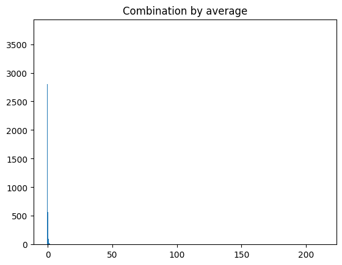

```python
# Import necessary modules for combination
from pyod.models.combination import aom, moa, average, maximization
from pyod.utils.utility import standardizer

# Define a range of k-neighbors to test
k_list = [10, 20, 30, 40, 50, 60, 70, 80, 90, 100, 110, 120, 130, 140, 150, 160, 170, 180, 190, 200]
n_clf = len(k_list)

# Initialize arrays to store the decision scores for each k-NN model
train_scores = np.zeros([X_train_scaled.shape[0], n_clf])
test_scores = np.zeros([X_test_scaled.shape[0], n_clf])

# Train multiple k-NN models and store decision scores for each model
for i, k in enumerate(k_list):
    clf = KNN(n_neighbors=k, method='largest')
    clf.fit(X_train_scaled)

    # Store decision function scores
    train_scores[:, i] = clf.decision_function(X_train_scaled)
    test_scores[:, i] = clf.decision_function(X_test_scaled)

# Normalize the decision scores before combining
train_scores_norm, test_scores_norm = standardizer(train_scores, test_scores)

# Use the "average" combination method to combine the decision scores from all k-NN models
train_scores_combined = average(train_scores_norm)
test_scores_combined = average(test_scores_norm)

# Combination by average
# The "average" function will take the average of the 12 columns.
# The result "y_by_average" is a single column:
y_train_by_average = average(train_scores_norm)
y_test_by_average = average(test_scores_norm)
plt.hist(y_train_by_average, bins='auto')
plt.title("Combination by average")
plt.show()
```

```python
descriptive_stat_threshold(X_train,y_train_by_average, 1)
```

|  | Group | Count | Percentage | Payment_to_Charge_Ratio | Discharges_per_Dollar | Average_Payment_per_Discharge | Coverage_Ratio | Discharges_per_Medicare_Payment | hospital_efficiency_score | charge_to_payment_ratio | discharge_efficiency | Avg Covered Charge Deviation | Provider Type Discharge Deviation | Weighted DRG Complexity Score | Patient Complexity Ratio | Anomaly_Score |
| --- | --- | --- | --- | --- | --- | --- | --- | --- | --- | --- | --- | --- | --- | --- | --- | --- |
| 0 | Anomaly | 2873 | 2.516974 | 0.29 | 0.02 | 922.43 | 0.84 | 0.02 | 4970.24 | 5.03 | 4970.24 | 1.08 | 2.16 | 5118.52 | 6.71 | 2.66 |
| 1 | Normal | 111272 | 97.483026 | 0.29 | 0.01 | 342.71 | 0.85 | 0.01 | 1421.78 | 3.74 | 1421.78 | -0.03 | -0.05 | 566.51 | 0.63 | -0.07 |

```python
descriptive_stat_threshold(X_test,y_test_by_average, 0.5)
```

|  | Group | Count | Percentage | Payment_to_Charge_Ratio | Discharges_per_Dollar | Average_Payment_per_Discharge | Coverage_Ratio | Discharges_per_Medicare_Payment | hospital_efficiency_score | charge_to_payment_ratio | discharge_efficiency | Avg Covered Charge Deviation | Provider Type Discharge Deviation | Weighted DRG Complexity Score | Patient Complexity Ratio | Anomaly_Score |
| --- | --- | --- | --- | --- | --- | --- | --- | --- | --- | --- | --- | --- | --- | --- | --- | --- |
| 0 | Anomaly | 3099 | 6.334832 | 0.28 | 0.01 | 732.02 | 0.84 | 0.02 | 3839.04 | 5.04 | 3839.04 | 0.98 | 1.38 | 2812.76 | 3.19 | 1.36 |
| 1 | Normal | 45821 | 93.665168 | 0.29 | 0.01 | 331.86 | 0.85 | 0.01 | 1363.43 | 3.70 | 1363.43 | -0.06 | -0.10 | 522.82 | 0.60 | -0.10 |

### KNN Analysis Takeaways

#### 1. Combination by Average:

We applied **KNN anomaly detection** with a range of k-neighbor values (10 to 200) and combined the decision scores using the **average** method. The majority of data points had low anomaly scores, indicating most are normal, with fewer points classified as anomalies.

#### 2. Descriptive Statistics (Training Set):

With a threshold of **1**, about **2.52%** of the training data were anomalies. Key metrics for anomalies showed:

- **Higher Average Payment per Discharge**: \$922.43 vs. \$342.71 for normal points.
- **Higher Hospital Efficiency Scores**: 4970.24 vs. 1421.78, indicating potential inefficiencies or irregularities.

#### 3. Descriptive Statistics (Test Set):

Using a threshold of **0.5**, anomalies made up **6.33%** of the test set. The anomalies similarly showed higher payment values and efficiency scores compared to normal points.

#### 4. Conclusion:

The KNN model successfully flagged anomalies that exhibited higher payments, hospital efficiency, and discharge efficiency. These anomalies warrant further investigation as they may indicate over-utilization, overbilling, or inefficiencies. Fine-tuning the threshold and combining results could further enhance detection accuracy.

## Principal Component Analysis (PCA)

Principal Component Analysis (PCA) is a dimensionality reduction technique that helps identify the most important components (directions) in the data that explain the maximum variance. This step will help reduce the complexity of our dataset while retaining the key information needed for anomaly detection.

### Data Preparation for PCA

Before applying PCA, we need to ensure that our data is in the correct format. PCA in the `pyod` library requires the input data to be in the form of a **NumPy array**. We will check if the data is in `DataFrame` format and convert it to NumPy if necessary. Additionally, we will ensure the data is already standardized.

```python
# Convert to NumPy arrays if necessary
X_train_scaled_np = X_train_scaled.to_numpy() if isinstance(X_train_scaled, pd.DataFrame) else X_train_scaled
X_test_scaled_np = X_test_scaled.to_numpy() if isinstance(X_test_scaled, pd.DataFrame) else X_test_scaled

# Verify the shape of the arrays
print("Shape of X_train_scaled_np:", X_train_scaled_np.shape)
print("Shape of X_test_scaled_np:", X_test_scaled_np.shape)
```

```
Shape of X_train_scaled_np: (114145, 12)
Shape of X_test_scaled_np: (48920, 12)
```

### Applying PCA for Anomaly Detection

Now that the data is prepared, we will apply **PCA** for anomaly detection using the `pyod` library. PCA will transform the data into a lower-dimensional space using **principal components**. We set the contamination rate to **5%** (expecting 5% of the data to be anomalies) and specify the number of components.

```python
# Import the PCA model from pyod
from pyod.models.pca import PCA

# Initialize the PCA model with 5% contamination and 10 principal components
pca = PCA(contamination=0.05, n_components=10, whiten=True)

# Fit the PCA model on the training data
pca.fit(X_train_scaled_np)

# Get the prediction labels and outlier scores for the training dataset
y_train_pred_pca = pca.predict(X_train_scaled_np)  # Binary labels: 0 for normal, 1 for anomaly
y_train_scores_pca = pca.decision_function(X_train_scaled_np)  # Outlier scores for the training data

# Print the PCA anomaly detection threshold
print(f"PCA Anomaly Detection Threshold: {pca.threshold_}")
```

```
PCA Anomaly Detection Threshold: 2264.5341414784525
```

### Predict and Evaluate Anomalies

Using the fitted PCA model, we will predict the anomalies and calculate the outlier scores for both the training and test datasets. The scores will help us visualize how the PCA model distinguishes between normal and anomalous points based on the learned principal components.

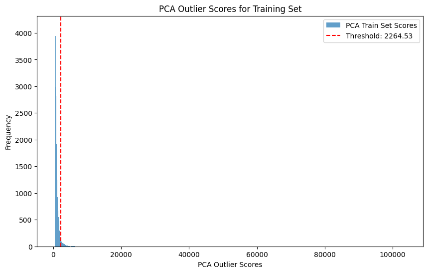

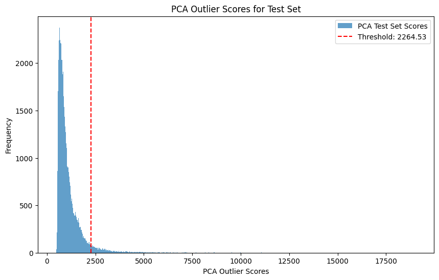

```python
# Get prediction labels and outlier scores for the test dataset
y_test_pred_pca = pca.predict(X_test_scaled_np)  # Binary labels: 0 for normal, 1 for anomaly
y_test_scores_pca = pca.decision_function(X_test_scaled_np)  # Outlier scores for the test data

# Plot histogram for the PCA outlier scores for the training set
plt.figure(figsize=(10, 6))
plt.hist(y_train_scores_pca, bins='auto', alpha=0.7, label='PCA Train Set Scores')
plt.axvline(pca.threshold_, color='r', linestyle='--', label=f'Threshold: {pca.threshold_:.2f}')
plt.title('PCA Outlier Scores for Training Set')
plt.xlabel('PCA Outlier Scores')
plt.ylabel('Frequency')
plt.legend()
plt.show()

# Plot histogram for the PCA outlier scores for the test set
plt.figure(figsize=(10, 6))
plt.hist(y_test_scores_pca, bins='auto', alpha=0.7, label='PCA Test Set Scores')
plt.axvline(pca.threshold_, color='r', linestyle='--', label=f'Threshold: {pca.threshold_:.2f}')
plt.title('PCA Outlier Scores for Test Set')
plt.xlabel('PCA Outlier Scores')
plt.ylabel('Frequency')
plt.legend()
plt.show()
```

### Takeaways from PCA Outlier Scores Visuals

- **PCA Threshold**: The anomaly detection threshold was set at **2264.53**, as indicated by the red dashed line in both the training and test set histograms. Any data points with PCA outlier scores above this threshold are classified as anomalies.
- **Training Set**:
  - The vast majority of data points have low PCA outlier scores, clustering around the lower end of the spectrum.
  - Very few points exceed the threshold, which is consistent with the 5% contamination rate we set, meaning we expect around 5% of the data to be classified as anomalies.
- **Test Set**:
  - Similarly, most points in the test set also have low PCA outlier scores, with only a small percentage of points exceeding the threshold.
  - The distribution of test scores aligns with the training set, indicating that the model generalizes well across both datasets.
- **Conclusion**: The PCA model has successfully reduced the dimensionality of the data and detected anomalies based on the principal components. Points with higher outlier scores deviate significantly from the normal patterns, suggesting potential anomalies in resource usage, payments, or efficiencies within the dataset.

### Descriptive Statistics for Anomalies and Normal Points

To better understand the nature of the anomalies detected by PCA, we will compute the descriptive statistics for both anomalies and normal points in the **training** and **test** datasets. This will help us analyze how the features differ between the two groups and identify any notable patterns or outliers.

We will use the PCA outlier scores and group the data into **"Anomalies"** and **"Normal"** based on the PCA threshold. The summary statistics will provide insights into the differences between these groups.

```python
# Calculate descriptive statistics for the training set
descriptive_stat_threshold(X_train_scaled_np, y_train_scores_pca, pca.threshold_)
```

|  | Group | Count | Percentage | Payment_to_Charge_Ratio | Discharges_per_Dollar | Average_Payment_per_Discharge | Coverage_Ratio | Discharges_per_Medicare_Payment | hospital_efficiency_score | charge_to_payment_ratio | discharge_efficiency | Avg Covered Charge Deviation | Provider Type Discharge Deviation | Weighted DRG Complexity Score | Patient Complexity Ratio | Anomaly_Score |
| --- | --- | --- | --- | --- | --- | --- | --- | --- | --- | --- | --- | --- | --- | --- | --- | --- |
| 0 | Anomaly | 5708 | 5.000657 | -0.12 | 1.33 | 1.59 | 0.22 | 1.34 | 1.84 | 0.74 | 1.84 | 0.99 | 1.42 | 1.07 | 0.48 | 3486.98 |
| 1 | Normal | 108437 | 94.999343 | 0.01 | -0.07 | -0.08 | -0.01 | -0.07 | -0.10 | -0.04 | -0.10 | -0.05 | -0.07 | -0.06 | -0.03 | 981.37 |

```python
# Calculate descriptive statistics for the test set
descriptive_stat_threshold(X_test_scaled_np, y_test_scores_pca, pca.threshold_)
```

|  | Group | Count | Percentage | Payment_to_Charge_Ratio | Discharges_per_Dollar | Average_Payment_per_Discharge | Coverage_Ratio | Discharges_per_Medicare_Payment | hospital_efficiency_score | charge_to_payment_ratio | discharge_efficiency | Avg Covered Charge Deviation | Provider Type Discharge Deviation | Weighted DRG Complexity Score | Patient Complexity Ratio | Anomaly_Score |
| --- | --- | --- | --- | --- | --- | --- | --- | --- | --- | --- | --- | --- | --- | --- | --- | --- |
| 0 | Anomaly | 2393 | 4.89166 | -0.09 | 1.30 | 1.56 | 0.25 | 1.30 | 1.86 | 0.78 | 1.86 | 1.03 | 1.34 | 0.97 | 0.42 | 3430.02 |
| 1 | Normal | 46527 | 95.10834 | 0.00 | -0.07 | -0.08 | -0.01 | -0.07 | -0.09 | -0.03 | -0.09 | -0.05 | -0.08 | -0.06 | -0.03 | 981.37 |

### Summary of Descriptive Statistics for PCA Anomaly Detection

#### Conclusion:

The PCA model successfully distinguishes between normal points and anomalies based on various financial and efficiency-related features. Anomalies represent data points with significantly higher payments, inefficiencies, and complexity, making them important candidates for further investigation regarding potential fraud, overbilling, or resource mismanagement.

## (Extra) Fit PCA with Different Numbers of Components and Calculate Explained Variance

In this step, we apply PCA to our scaled training dataset without specifying the number of components. This allows PCA to compute all the principal components and calculate the **explained variance ratio** for each one. The explained variance ratio indicates the proportion of the dataset's variance that is explained by each principal component.

We then plot the **cumulative explained variance** to help us understand how many components are needed to capture most of the variance in the dataset. This plot will guide our decision on the number of components to use for further anomaly detection.

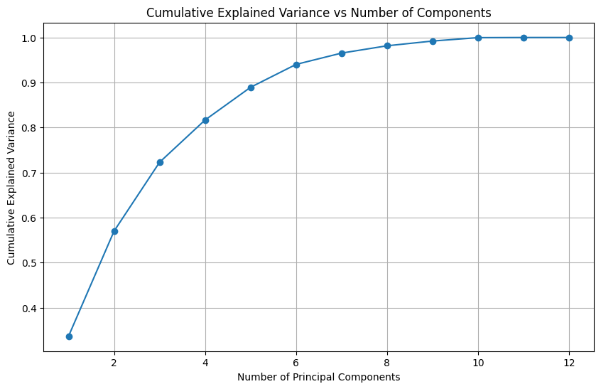

```python
# Importing necessary libraries
from sklearn.decomposition import PCA

# Applying PCA to the training data without specifying the number of components
pca = PCA(n_components=None)  # None means we calculate all possible components
pca.fit(X_train_scaled_np)

# Calculate explained variance for each component
exp_variance = np.cumsum(pca.explained_variance_ratio_)

# Plot the cumulative explained variance
plt.figure(figsize=(10, 6))
plt.plot(range(1, len(exp_variance) + 1), exp_variance, marker='o')
plt.xlabel('Number of Principal Components')
plt.ylabel('Cumulative Explained Variance')
plt.title('Cumulative Explained Variance vs Number of Components')
plt.grid(True)
plt.show()
```

### PCA Outlier Detection (Direct Outlier Scores)

[figure not shown]

```python
# Apply PCA with 6 components
pca_selected = PCA(n_components=6)
pca_selected.fit(X_train_scaled_np)

# Transform the training and test data into the PCA space
X_train_pca = pca_selected.transform(X_train_scaled_np)

# Calculate the PCA outlier scores (the sum of squares of the principal components)
train_pca_outlier_scores = np.sum(X_train_pca**2, axis=1)

# Plot the histogram of PCA outlier scores for the training set
plt.figure(figsize=(10, 6))
plt.hist(train_pca_outlier_scores, bins='auto', alpha=0.7, label='Train Set PCA Outlier Scores')
plt.title('Histogram of PCA Outlier Scores for Training Set')
plt.xlabel('PCA Outlier Scores')
plt.ylabel('Frequency')
plt.grid(True)
plt.legend()
plt.show()
```

### Zooming into PCA Outlier Scores Below 5000

To better visualize the majority of data points, we will limit the histogram to PCA outlier scores below 5000. This allows us to focus on the most frequent values and ignore the extreme outliers for now.

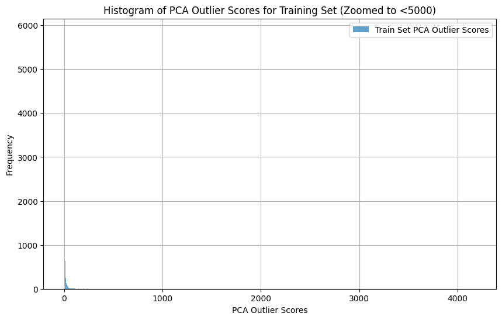

```python
# Filter PCA outlier scores to values below 5000
filtered_train_pca_outlier_scores = train_pca_outlier_scores[train_pca_outlier_scores < 5000]

# Plot the histogram of PCA outlier scores for the training set (zoomed in)
plt.figure(figsize=(10, 6))
plt.hist(filtered_train_pca_outlier_scores, bins='auto', alpha=0.7, label='Train Set PCA Outlier Scores')
plt.title('Histogram of PCA Outlier Scores for Training Set (Zoomed to <5000)')
plt.xlabel('PCA Outlier Scores')
plt.ylabel('Frequency')
plt.grid(True)
plt.legend()
plt.show()
```

```python
# Check mean and standard deviation of scaled data to ensure it's standardized
print(f"Mean of X_train_scaled_np: {np.mean(X_train_scaled_np, axis=0)}")
print(f"Standard deviation of X_train_scaled_np: {np.std(X_train_scaled_np, axis=0)}")
```

```
Mean of X_train_scaled_np: [ 7.23334933e-17 -3.78474732e-17  1.46160966e-16  9.79614616e-16
 -5.47792376e-17  9.95986138e-18 -1.29104703e-16  9.95986138e-18
 -1.76476294e-17 -1.29478198e-17  1.23253285e-17 -2.68916257e-17]
Standard deviation of X_train_scaled_np: [1. 1. 1. 1. 1. 1. 1. 1. 1. 1. 1. 1.]
```

### Normalizing PCA Outlier Scores

```python
from sklearn.preprocessing import StandardScaler

# Initialize the scaler
scaler = StandardScaler()

# Reshape the scores to 2D for scaling
y_train_scores_reshaped = y_train_scores.reshape(-1, 1)

# Apply scaling
train_scores_normalized = scaler.fit_transform(y_train_scores_reshaped)

# Zoom in further to PCA outlier scores below 10
plt.figure(figsize=(10, 6))
plt.hist([score for score in train_scores_normalized if score <= 10], bins='auto', alpha=0.7, label='Train Set PCA Outlier Scores (Zoomed In)')
plt.title('Histogram of Normalized PCA Outlier Scores for Training Set (Zoomed to <10)')
plt.xlabel('PCA Outlier Scores (Normalized)')
plt.ylabel('Frequency')
plt.legend()
plt.show()
```

[output not shown]

### Reflections on the Unfinished PCA Component Analysis

In this section, I aimed to extend the PCA-based anomaly detection by experimenting with different numbers of principal components. Initially, I selected six components based on the cumulative explained variance, intending to balance dimensionality reduction with information retention. My plan was to visualize the PCA outlier scores as a histogram to manually determine an optimal threshold for anomaly detection.